# Final Project- Sarcopenia Risk Predictor

# 2. RandomForestClassifier

```python
# Select features for Model 2
features = ['Age', 'Weight', 'Height', 'Exercise', 'DM', 'Smoking', 'HT', 'Education', 'BMI', 'Smoking (packet/year)', 'Alcohol', 'CST', 'Gait speed']  # Added CST and GSP
target = 'SARCOPENIA'
```

```python
# Split the dataset by gender for separate models
male_df = data[data['Gender'] == 0]
female_df = data[data['Gender'] == 1]
```

```python
# Function to prepare data, fit the model, save it, and return the model along with the feature names
def fit_random_forest(dataframe, features, target, filename):
    X = dataframe[features]
    y = dataframe[target]

    # Train-test split
    X_train, X_test, y_train, y_test = train_test_split(X, y, test_size=0.3, random_state=42)

    # Scale features
    scaler = StandardScaler()
    X_train_scaled = scaler.fit_transform(X_train)
    X_test_scaled = scaler.transform(X_test)

    # Fit Random Forest
    model = RandomForestClassifier(n_estimators=100, random_state=42)
    model.fit(X_train_scaled, y_train)

    # Output the classification report and confusion matrix
    y_pred = model.predict(X_test_scaled)
    print(classification_report(y_test, y_pred))
    print(confusion_matrix(y_test, y_pred))

    # Save the model to a pickle file correctly before returning
    with open(filename, 'wb') as f:
        pickle.dump(model, f)

    return model, X_test.columns
```

```python
# Function to plot feature importance
def plot_feature_importance(importances, feature_names, title):
    # Sort feature importances in descending order
    indices = np.argsort(importances)[::-1]

    # Rearrange feature names so they match the sorted feature importances
    names = [feature_names[i] for i in indices]

    # Create plot
    plt.figure(figsize=(10, 6))

    # Create plot title
    plt.title(title)

    # Add bars
    plt.bar(range(len(importances)), importances[indices])

    # Add feature names as x-axis labels
    plt.xticks(range(len(importances)), names, rotation=90)

    # Show plot
    plt.show()
```

```
Male Model Feature Importance:
              precision    recall  f1-score   support

         0.0       0.85      0.96      0.90       230
         1.0       0.50      0.21      0.29        48

    accuracy                           0.83       278
   macro avg       0.68      0.58      0.60       278
weighted avg       0.79      0.83      0.80       278

[[220  10]
 [ 38  10]]
```

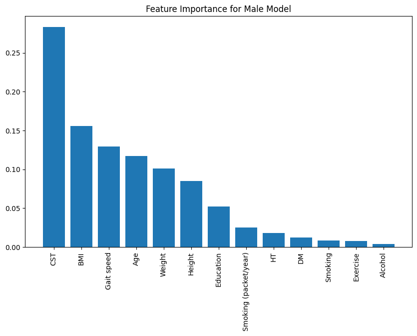

```python
# Example usage:
print("Male Model Feature Importance:")
male_model, male_features = fit_random_forest(male_df, features, target, 'male_random_forest_model.pkl')
plot_feature_importance(male_model.feature_importances_, features, 'Feature Importance for Male Model')
```

```
Female Model Feature Importance:
              precision    recall  f1-score   support

         0.0       0.88      0.93      0.90        90
         1.0       0.67      0.50      0.57        24

    accuracy                           0.84       114
   macro avg       0.77      0.72      0.74       114
weighted avg       0.83      0.84      0.83       114

[[84  6]
 [12 12]]
```

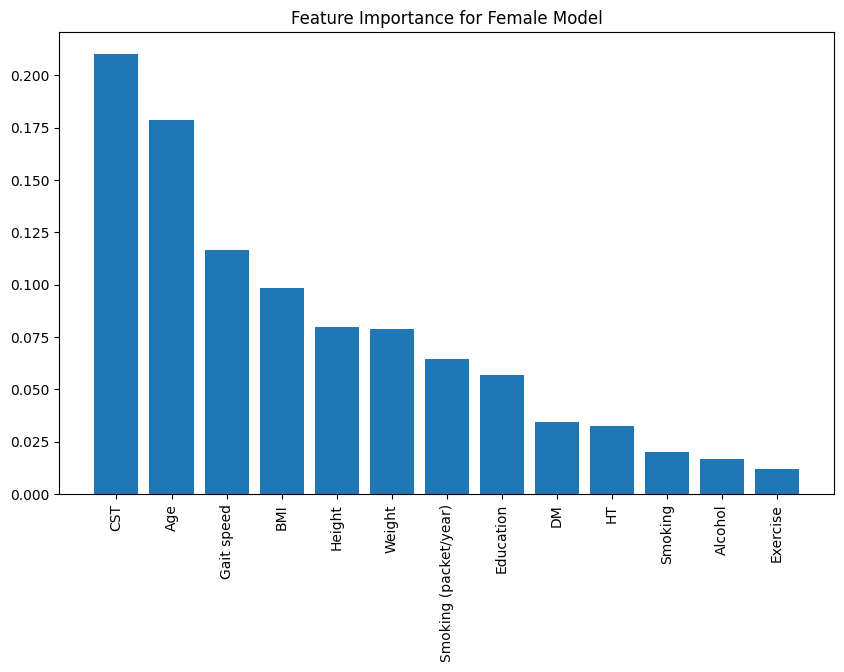

```python
# Similarly, for the female model...
print("\nFemale Model Feature Importance:")
female_model, female_features = fit_random_forest(female_df, features, target, 'female_random_forest_model.pkl')
plot_feature_importance(female_model.feature_importances_, features, 'Feature Importance for Female Model')
```

```python
# Files are 'male_random_forest_model.pkl' and 'female_random_forest_model.pkl'

files.download('male_random_forest_model.pkl')
files.download('female_random_forest_model.pkl')
```

# 3. GradientBoostingClassifier

```python
# Select features for Model 3
features = [ 'Age', 'Weight', 'Height', 'Exercise', 'DM', 'Smoking', 'HT',
    'Education', 'BMI', 'Smoking (packet/year)', 'Alcohol', 'CST', 'Gait speed', 'Grip strength']  # Added GRS
target = 'SARCOPENIA'
```

```python
# Split the dataset by gender for separate models
male_df = data[data['Gender'] == 0]
female_df = data[data['Gender'] == 1]
```

```python
# Function to prepare data, fit the model, save it, and return the model and feature names
def fit_gradient_boosting(dataframe, features, target, filename):
    X = dataframe[features]
    y = dataframe[target]

    # Train-test split
    X_train, X_test, y_train, y_test = train_test_split(X, y, test_size=0.3, random_state=42)

    # Scale features
    scaler = StandardScaler()
    X_train_scaled = scaler.fit_transform(X_train)
    X_test_scaled = scaler.transform(X_test)

    # Fit Gradient Boosting
    model = GradientBoostingClassifier(n_estimators=100, learning_rate=0.1, max_depth=3, random_state=42)
    model.fit(X_train_scaled, y_train)

    # Output the classification report and confusion matrix
    y_pred = model.predict(X_test_scaled)
    print(classification_report(y_test, y_pred))
    print(confusion_matrix(y_test, y_pred))

    # Save the model to a pickle file
    with open(filename, 'wb') as f:
        pickle.dump(model, f)

    # Return only the model and the names of the features used
    return model, X_train.columns.tolist()
```

```python
# Function to plot feature importance for Gradient Boosting
def plot_feature_importance(importances, feature_names, title):
    # Create a dataframe of feature importances
    importance_df = pd.DataFrame({'Feature': feature_names, 'Importance': importances})
    importance_df = importance_df.sort_values('Importance', ascending=False)

    # Plot
    plt.figure(figsize=(10, 6))
    plt.bar(importance_df['Feature'], importance_df['Importance'])
    plt.title(title)
    plt.xlabel('Features')
    plt.ylabel('Importance')
    plt.xticks(rotation=90)
    plt.show()
```

```
Male Model:
              precision    recall  f1-score   support

         0.0       0.88      0.95      0.92       230
         1.0       0.63      0.40      0.49        48

    accuracy                           0.86       278
   macro avg       0.76      0.67      0.70       278
weighted avg       0.84      0.86      0.84       278

[[219  11]
 [ 29  19]]
```

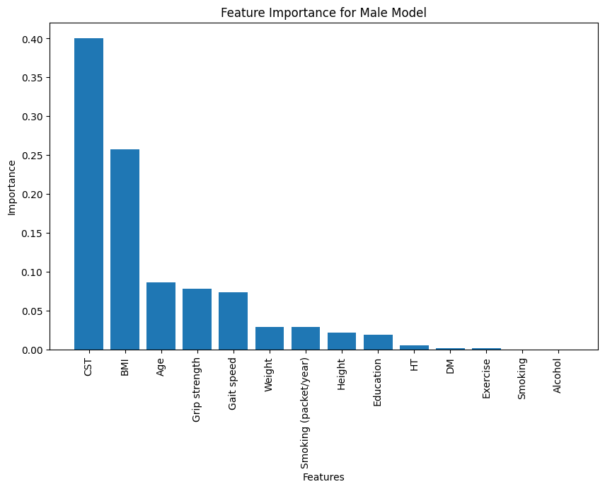

```python
# Fit, predict, and plot feature importance for the male model
print("Male Model:")
male_model, male_features = fit_gradient_boosting(male_df, features, target, 'male_gradient_boosting_model.pkl')
plot_feature_importance(male_model.feature_importances_, male_features, 'Feature Importance for Male Model')
```

```
Female Model:
              precision    recall  f1-score   support

         0.0       0.93      0.90      0.92        90
         1.0       0.67      0.75      0.71        24

    accuracy                           0.87       114
   macro avg       0.80      0.82      0.81       114
weighted avg       0.88      0.87      0.87       114

[[81  9]
 [ 6 18]]
```

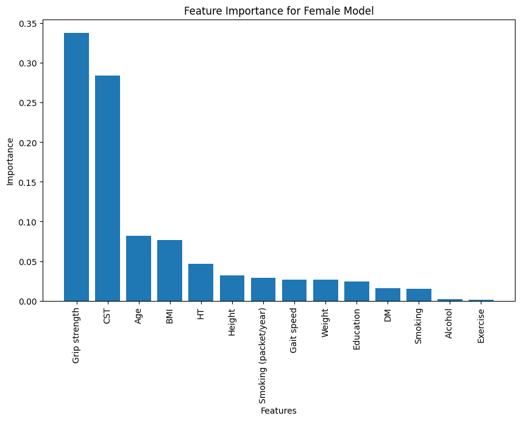

```python
# Fit, predict, and plot feature importance for the female model
print("\nFemale Model:")
female_model, female_features = fit_gradient_boosting(female_df, features, target, 'female_gradient_boosting_model.pkl')
plot_feature_importance(female_model.feature_importances_, female_features, 'Feature Importance for Female Model')
```

```python
# Download the model files
files.download('male_gradient_boosting_model.pkl')
files.download('female_gradient_boosting_model.pkl')
```

# Streamlit

- We create a simple Streamlit web application which takes in data from the user and calculates the probabilities based on three models.

Instruction

1. Open Terminal.
2. Navigate to the working folder named 'FinalProject'.
3. The folder contains pickle files for both males and females for the three models, the preprocessed data file 'Data.csv', and the file 'streamlit_app.py'.
4. Install Streamlit in your terminal using the command: pip install streamlit.
5. Enter the command: streamlit run streamlit_app.py.
6. Then enter the values for the features for the three models, which are specified as 'Home' for LogisticRegression, 'Clinical1' for RandomForestClassifier, and 'Clinical2' for GradientBoostingClassifier.